# TASK5_Exploratory Data Analysis on Sports

# GRIP @ The Spark Foundation

# Objective:Performing ‘Exploratory Data Analysis’ on ‘Indian Premier League’ dataset

As a sports analyst, I will find out the most successful teams, players and factors contributing win or loss of a team.Link to dataset: https://drive.google.com/file/d/18iDDIIZGt8eWxzqbyMIqcn5X7bHINuLw/view

#### IMPORTING LIBRARIES

```python
import numpy as np
import pandas as pd
import matplotlib.pyplot as plt
import seaborn as sns
import urllib3.request as p
```

#### IMPORTING DATASET

```python
df = pd.read_csv("matches.csv")
df1 = pd.read_csv("deliveries.csv")
```

```python
df.head()
```

|  | id | season | city | date | team1 | team2 | toss_winner | toss_decision | result | dl_applied | winner | win_by_runs | win_by_wickets | player_of_match | venue | umpire1 | umpire2 | umpire3 |
| --- | --- | --- | --- | --- | --- | --- | --- | --- | --- | --- | --- | --- | --- | --- | --- | --- | --- | --- |
| 0 | 1 | 2017 | Hyderabad | 2017-04-05 | Sunrisers Hyderabad | Royal Challengers Bangalore | Royal Challengers Bangalore | field | normal | 0 | Sunrisers Hyderabad | 35 | 0 | Yuvraj Singh | Rajiv Gandhi International Stadium, Uppal | AY Dandekar | NJ Llong | NaN |
| 1 | 2 | 2017 | Pune | 2017-04-06 | Mumbai Indians | Rising Pune Supergiant | Rising Pune Supergiant | field | normal | 0 | Rising Pune Supergiant | 0 | 7 | SPD Smith | Maharashtra Cricket Association Stadium | A Nand Kishore | S Ravi | NaN |
| 2 | 3 | 2017 | Rajkot | 2017-04-07 | Gujarat Lions | Kolkata Knight Riders | Kolkata Knight Riders | field | normal | 0 | Kolkata Knight Riders | 0 | 10 | CA Lynn | Saurashtra Cricket Association Stadium | Nitin Menon | CK Nandan | NaN |
| 3 | 4 | 2017 | Indore | 2017-04-08 | Rising Pune Supergiant | Kings XI Punjab | Kings XI Punjab | field | normal | 0 | Kings XI Punjab | 0 | 6 | GJ Maxwell | Holkar Cricket Stadium | AK Chaudhary | C Shamshuddin | NaN |
| 4 | 5 | 2017 | Bangalore | 2017-04-08 | Royal Challengers Bangalore | Delhi Daredevils | Royal Challengers Bangalore | bat | normal | 0 | Royal Challengers Bangalore | 15 | 0 | KM Jadhav | M Chinnaswamy Stadium | NaN | NaN | NaN |

```python
df1.head()
```

|  | match_id | inning | batting_team | bowling_team | over | ball | batsman | non_striker | bowler | is_super_over | ... | bye_runs | legbye_runs | noball_runs | penalty_runs | batsman_runs | extra_runs | total_runs | player_dismissed | dismissal_kind | fielder |
| --- | --- | --- | --- | --- | --- | --- | --- | --- | --- | --- | --- | --- | --- | --- | --- | --- | --- | --- | --- | --- | --- |
| 0 | 1 | 1 | Sunrisers Hyderabad | Royal Challengers Bangalore | 1 | 1 | DA Warner | S Dhawan | TS Mills | 0 | ... | 0 | 0 | 0 | 0 | 0 | 0 | 0 | NaN | NaN | NaN |
| 1 | 1 | 1 | Sunrisers Hyderabad | Royal Challengers Bangalore | 1 | 2 | DA Warner | S Dhawan | TS Mills | 0 | ... | 0 | 0 | 0 | 0 | 0 | 0 | 0 | NaN | NaN | NaN |
| 2 | 1 | 1 | Sunrisers Hyderabad | Royal Challengers Bangalore | 1 | 3 | DA Warner | S Dhawan | TS Mills | 0 | ... | 0 | 0 | 0 | 0 | 4 | 0 | 4 | NaN | NaN | NaN |
| 3 | 1 | 1 | Sunrisers Hyderabad | Royal Challengers Bangalore | 1 | 4 | DA Warner | S Dhawan | TS Mills | 0 | ... | 0 | 0 | 0 | 0 | 0 | 0 | 0 | NaN | NaN | NaN |
| 4 | 1 | 1 | Sunrisers Hyderabad | Royal Challengers Bangalore | 1 | 5 | DA Warner | S Dhawan | TS Mills | 0 | ... | 0 | 0 | 0 | 0 | 0 | 2 | 2 | NaN | NaN | NaN |

5 rows × 21 columns

#### Seeking information of Dataset

```python
df.info()
#attributes that will be used for further analysis
```

```
<class 'pandas.core.frame.DataFrame'>
RangeIndex: 756 entries, 0 to 755
Data columns (total 18 columns):
 #   Column           Non-Null Count  Dtype
---  ------           --------------  -----
 0   id               756 non-null    int64
 1   season           756 non-null    int64
 2   city             749 non-null    object
 3   date             756 non-null    object
 4   team1            756 non-null    object
 5   team2            756 non-null    object
 6   toss_winner      756 non-null    object
 7   toss_decision    756 non-null    object
 8   result           756 non-null    object
 9   dl_applied       756 non-null    int64
 10  winner           752 non-null    object
 11  win_by_runs      756 non-null    int64
 12  win_by_wickets   756 non-null    int64
 13  player_of_match  752 non-null    object
 14  venue            756 non-null    object
 15  umpire1          754 non-null    object
 16  umpire2          754 non-null    object
 17  umpire3          119 non-null    object
dtypes: int64(5), object(13)
memory usage: 106.4+ KB
```

id - id of the match

season - season of ipl

city - the city at which the match is held

date - date

team1 & team2 - names of the teams

toss_winner - winner of the toss

toss_decision - bat/bowl

result - normal/tie/no result

dl_applied - due to any reasons dl method is applied?(binary value 0 or 1)

win_by_runs - win by runs

win_by_wickets - win by wickets

player_of_match - man of the match

venue - stadium

umpire1,2,3 - names of umpires

```python
df1.info()
```

```
<class 'pandas.core.frame.DataFrame'>
RangeIndex: 179078 entries, 0 to 179077
Data columns (total 21 columns):
 #   Column            Non-Null Count   Dtype
---  ------            --------------   -----
 0   match_id          179078 non-null  int64
 1   inning            179078 non-null  int64
 2   batting_team      179078 non-null  object
 3   bowling_team      179078 non-null  object
 4   over              179078 non-null  int64
 5   ball              179078 non-null  int64
 6   batsman           179078 non-null  object
 7   non_striker       179078 non-null  object
 8   bowler            179078 non-null  object
 9   is_super_over     179078 non-null  int64
 10  wide_runs         179078 non-null  int64
 11  bye_runs          179078 non-null  int64
 12  legbye_runs       179078 non-null  int64
 13  noball_runs       179078 non-null  int64
 14  penalty_runs      179078 non-null  int64
 15  batsman_runs      179078 non-null  int64
 16  extra_runs        179078 non-null  int64
 17  total_runs        179078 non-null  int64
 18  player_dismissed  8834 non-null    object
 19  dismissal_kind    8834 non-null    object
 20  fielder           6448 non-null    object
dtypes: int64(13), object(8)
memory usage: 28.7+ MB
```

match_id - id of match

inning - 1st or 2nd

batting_team - batting team

bowling_team - bowling team

over - over in the innings

ball - ball number in the over

batsman - name of batsman on strike

non_striker - name of batsman at non-striker end

bowler - name of bowler

vis_super_over - binary value 0 or 1(yes/no)

wide_runs - how many runs consided by wide

bye_runs - bye runs

legbye_runs - leg bye runs

noball_runs - no ball runs

penalty_runs - penalty runs

batsman_runs - batsman runs

total_runs - total runs for the ball

player_dismissed - name of the batsman dismissed

dismissal_kind - how the bastman is dismissed(LBW/Hitwicket/runout ..etc)

fielder - named of the fielder who catched the ball

#### Details on Toss won by each team, Total Matches played so far, total matches being won list.

```python
team_stats = pd.DataFrame({'Total Matches played': df.team1.value_counts() + df.team2.value_counts(), 'Total won': df.winner.value_counts(), 'Toss won': df.toss_winner.value_counts(),
                          'Total lost': ((df.team1.value_counts() + df.team2.value_counts()) - df.winner.value_counts())})
team_stats = team_stats.reset_index()
team_stats.rename(columns = {'index':'Teams'}, inplace = True)
winloss = team_stats['Total won'] / team_stats['Total Matches played']
winloss = pd.DataFrame({'Winloss Ratio': team_stats['Total won'] / team_stats['Total Matches played']})
winloss= winloss.round(2)
team_stats = team_stats.join(winloss)
team_stats
```

|  | Teams | Total Matches played | Total won | Toss won | Total lost | Winloss Ratio |
| --- | --- | --- | --- | --- | --- | --- |
| 0 | Chennai Super Kings | 164 | 100 | 89 | 64 | 0.61 |
| 1 | Deccan Chargers | 75 | 29 | 43 | 46 | 0.39 |
| 2 | Delhi Capitals | 16 | 10 | 10 | 6 | 0.62 |
| 3 | Delhi Daredevils | 161 | 67 | 80 | 94 | 0.42 |
| 4 | Gujarat Lions | 30 | 13 | 15 | 17 | 0.43 |
| 5 | Kings XI Punjab | 176 | 82 | 81 | 94 | 0.47 |
| 6 | Kochi Tuskers Kerala | 14 | 6 | 8 | 8 | 0.43 |
| 7 | Kolkata Knight Riders | 178 | 92 | 92 | 86 | 0.52 |
| 8 | Mumbai Indians | 187 | 109 | 98 | 78 | 0.58 |
| 9 | Pune Warriors | 46 | 12 | 20 | 34 | 0.26 |
| 10 | Rajasthan Royals | 147 | 75 | 80 | 72 | 0.51 |
| 11 | Rising Pune Supergiant | 16 | 10 | 6 | 6 | 0.62 |
| 12 | Rising Pune Supergiants | 14 | 5 | 7 | 9 | 0.36 |
| 13 | Royal Challengers Bangalore | 180 | 84 | 81 | 96 | 0.47 |
| 14 | Sunrisers Hyderabad | 108 | 58 | 46 | 50 | 0.54 |

#### Maximum Toss Won:

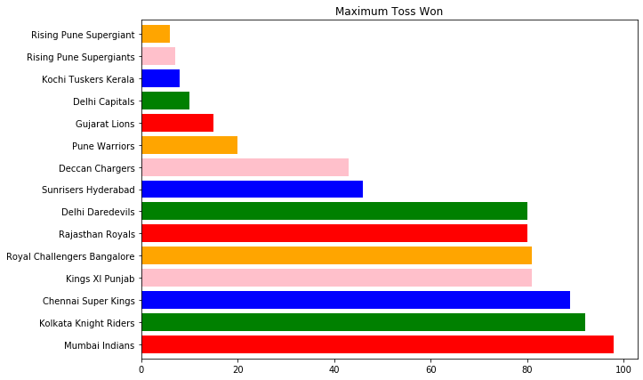

```python
plt.subplots(figsize=(10,7))
ax=df['toss_winner'].value_counts().plot.barh(width=0.8,color=['red', 'green','blue','pink','orange'])
plt.title("Maximum Toss Won")
```

As you know in cricket toss plays a mojor role , the team which wins the toss has a heigher advantage. mumbai indians has won maximum no.of toss in IPL

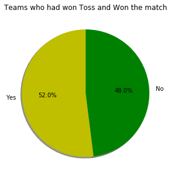

```python
Tosswin_matchwin=df[df['toss_winner']==df['winner']]
slices=[len(Tosswin_matchwin),(len(df)-len(Tosswin_matchwin))]
labels=['Yes','No']
plt.pie(slices,labels=labels,startangle=90,shadow=True,explode=(0,0),autopct='%1.1f%%',colors=['y','g'])
plt.title("Teams who had won Toss and Won the match")
fig = plt.gcf()
fig.set_size_inches(5,5)
plt.show()
#The Chances of the team winning, if it has won the toss are reasonably high.
#Toss favours to the victory of team
```

#### Plotting the above data Analysis - Total Won

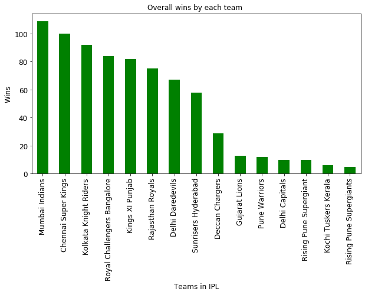

```python
Total_win = df.winner.value_counts()
ax = Total_win.plot(kind='bar',title ="Overall wins by each team ",figsize=(10,5), fontsize=12,color='green')
ax.set_xlabel("Teams in IPL",fontsize=12)
ax.set_ylabel("Wins",fontsize=12)
```

#### Seeking shape as in rows and columns in our dataset

```python
df.shape
```

```
(756, 18)
```

```python
df1.describe()
```

|  | match_id | inning | over | ball | is_super_over | wide_runs | bye_runs | legbye_runs | noball_runs | penalty_runs | batsman_runs | extra_runs | total_runs |
| --- | --- | --- | --- | --- | --- | --- | --- | --- | --- | --- | --- | --- | --- |
| count | 179078.000000 | 179078.000000 | 179078.000000 | 179078.000000 | 179078.000000 | 179078.000000 | 179078.000000 | 179078.000000 | 179078.000000 | 179078.000000 | 179078.000000 | 179078.000000 | 179078.000000 |
| mean | 1802.252957 | 1.482952 | 10.162488 | 3.615587 | 0.000452 | 0.036721 | 0.004936 | 0.021136 | 0.004183 | 0.000056 | 1.246864 | 0.067032 | 1.313897 |
| std | 3472.322805 | 0.502074 | 5.677684 | 1.806966 | 0.021263 | 0.251161 | 0.116480 | 0.194908 | 0.070492 | 0.016709 | 1.608270 | 0.342553 | 1.605422 |
| min | 1.000000 | 1.000000 | 1.000000 | 1.000000 | 0.000000 | 0.000000 | 0.000000 | 0.000000 | 0.000000 | 0.000000 | 0.000000 | 0.000000 | 0.000000 |
| 25% | 190.000000 | 1.000000 | 5.000000 | 2.000000 | 0.000000 | 0.000000 | 0.000000 | 0.000000 | 0.000000 | 0.000000 | 0.000000 | 0.000000 | 0.000000 |
| 50% | 379.000000 | 1.000000 | 10.000000 | 4.000000 | 0.000000 | 0.000000 | 0.000000 | 0.000000 | 0.000000 | 0.000000 | 1.000000 | 0.000000 | 1.000000 |
| 75% | 567.000000 | 2.000000 | 15.000000 | 5.000000 | 0.000000 | 0.000000 | 0.000000 | 0.000000 | 0.000000 | 0.000000 | 1.000000 | 0.000000 | 1.000000 |
| max | 11415.000000 | 5.000000 | 20.000000 | 9.000000 | 1.000000 | 5.000000 | 4.000000 | 5.000000 | 5.000000 | 5.000000 | 7.000000 | 7.000000 | 10.000000 |

#### Seeking Description of our dataset

```python
df.describe()
```

|  | id | season | dl_applied | win_by_runs | win_by_wickets |
| --- | --- | --- | --- | --- | --- |
| count | 756.000000 | 756.000000 | 756.000000 | 756.000000 | 756.000000 |
| mean | 1792.178571 | 2013.444444 | 0.025132 | 13.283069 | 3.350529 |
| std | 3464.478148 | 3.366895 | 0.156630 | 23.471144 | 3.387963 |
| min | 1.000000 | 2008.000000 | 0.000000 | 0.000000 | 0.000000 |
| 25% | 189.750000 | 2011.000000 | 0.000000 | 0.000000 | 0.000000 |
| 50% | 378.500000 | 2013.000000 | 0.000000 | 0.000000 | 4.000000 |
| 75% | 567.250000 | 2016.000000 | 0.000000 | 19.000000 | 6.000000 |
| max | 11415.000000 | 2019.000000 | 1.000000 | 146.000000 | 10.000000 |

```python
df1['match_id'].max()
```

```
11415
```

#### Seasons represented in the dataset

```python
df['season'].unique()
```

```
array([2017, 2008, 2009, 2010, 2011, 2012, 2013, 2014, 2015, 2016, 2018,
       2019], dtype=int64)
```

```python
len(df['season'].unique())
```

```
12
```

```python
winner_each_season = df.drop_duplicates(subset=['season'],keep='last')[['season', 'winner']].reset_index(drop=True)
winner_each_season
```

|  | season | winner |
| --- | --- | --- |
| 0 | 2017 | Mumbai Indians |
| 1 | 2008 | Rajasthan Royals |
| 2 | 2009 | Deccan Chargers |
| 3 | 2010 | Chennai Super Kings |
| 4 | 2011 | Chennai Super Kings |
| 5 | 2012 | Kolkata Knight Riders |
| 6 | 2013 | Mumbai Indians |
| 7 | 2014 | Kolkata Knight Riders |
| 8 | 2015 | Mumbai Indians |
| 9 | 2016 | Sunrisers Hyderabad |
| 10 | 2018 | Chennai Super Kings |
| 11 | 2019 | Mumbai Indians |

#### Most wins

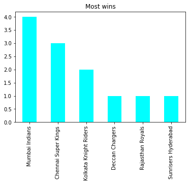

```python
winner_each_season.winner.value_counts().plot(kind='bar',orientation='vertical',title='Most wins',color='cyan')
```

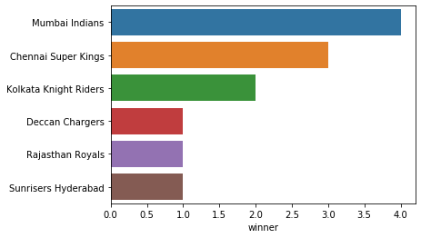

```python
data = winner_each_season.winner.value_counts()
sns.barplot(y = data.index, x = data, orient='h')
```

chennai won 3 times and mumbai indian 4 times

#### Team detail that won by maxium runs

```python
df.iloc[df['win_by_runs'].idxmax()]
```

```
id                               44
season                         2017
city                          Delhi
date                     2017-05-06
team1                Mumbai Indians
team2              Delhi Daredevils
toss_winner        Delhi Daredevils
toss_decision                 field
result                       normal
dl_applied                        0
winner               Mumbai Indians
win_by_runs                     146
win_by_wickets                    0
player_of_match         LMP Simmons
venue              Feroz Shah Kotla
umpire1                 Nitin Menon
umpire2                   CK Nandan
umpire3                         NaN
Name: 43, dtype: object
```

#### Each team comparison

[output not shown]

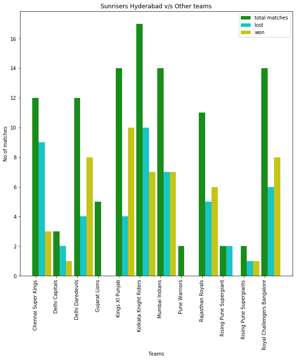

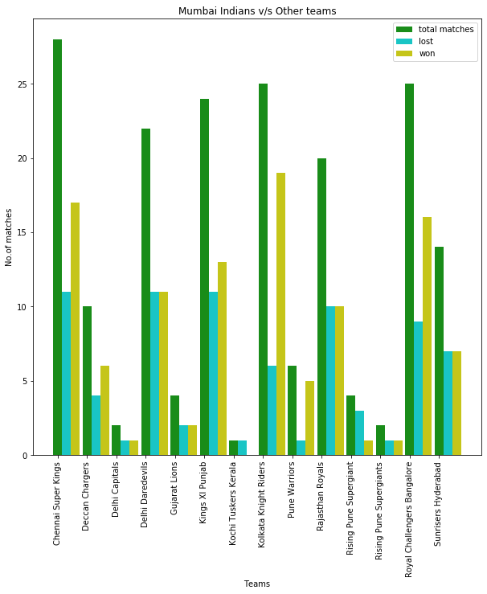

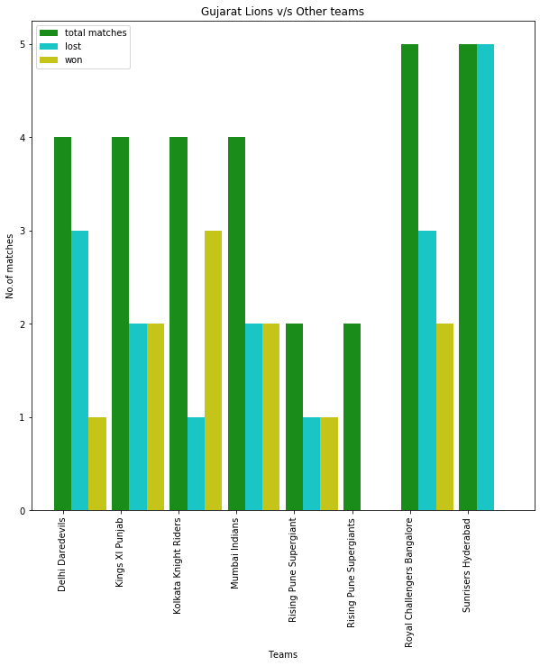

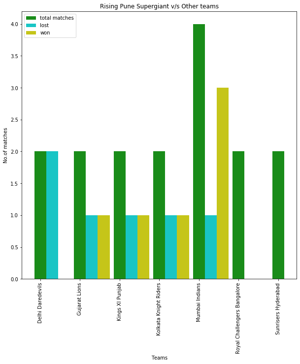

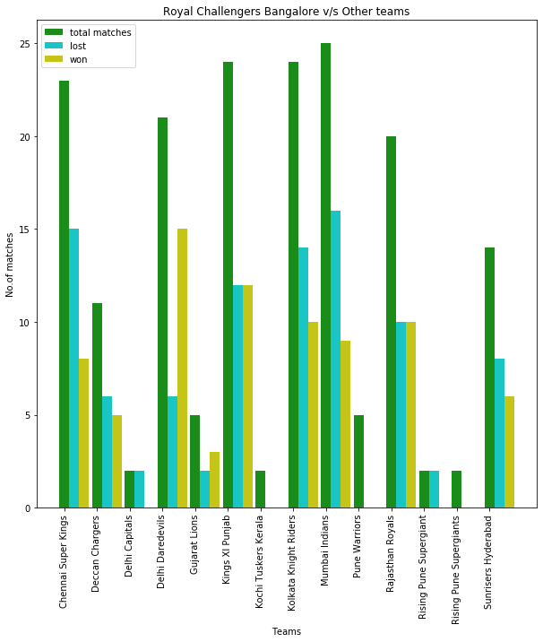

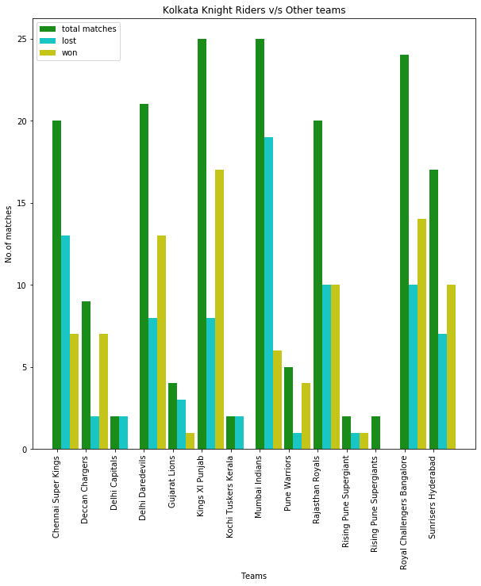

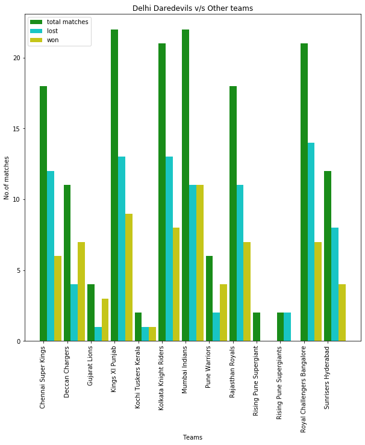

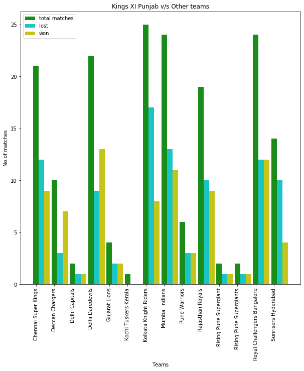

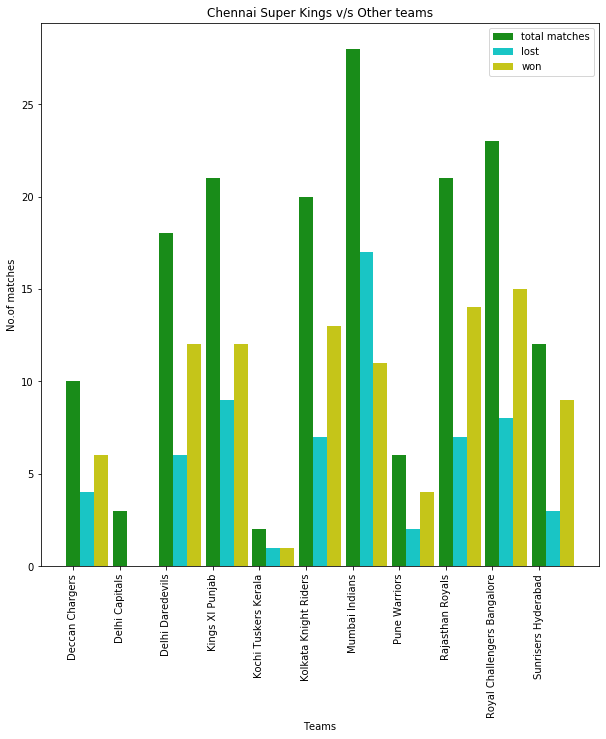

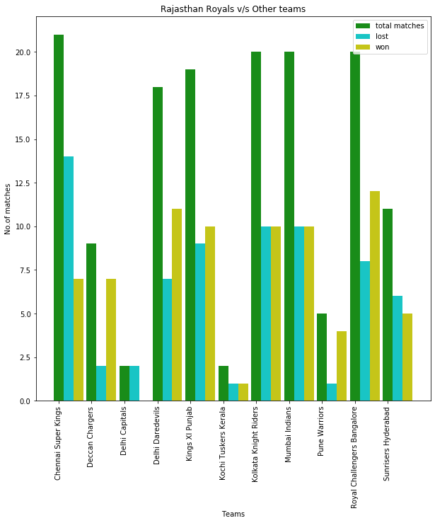

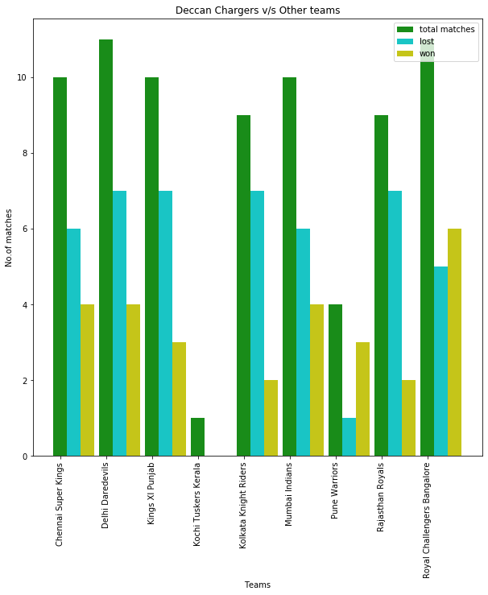

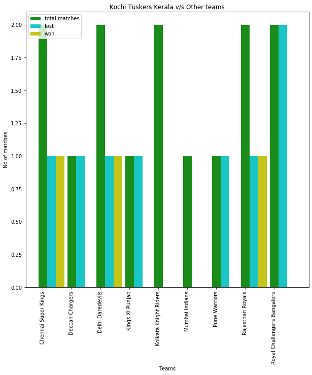

[3 more figures not shown]

```python
for i in df["team1"].unique():
    #print(i)
    new_df=df.copy()
    for j in range(len(df)):
        if (new_df["team1"][j] != i and new_df["team2"][j] == i):
            a=new_df["team1"][j]
            new_df["team1"][j]=new_df["team2"][j]
            new_df["team2"][j]=a
        elif(new_df["team1"][j] != i and new_df["team2"][j] != i):
            new_df=new_df.drop([j],axis=0)
    new_df["won"]=(new_df["winner"]==i).astype(int)
    #new_df.to_csv(i+'.csv')
    won=pd.DataFrame({'Total':new_df.team2.value_counts(),'won': new_df.winner.value_counts()})
    won=won.drop(index=i)
    fig,ax=plt.subplots(figsize=(10,10))
    bar_width = 0.3
    opacity = 0.9
    index=np.arange(len(won))
    ax.bar(index,won['Total'],bar_width, alpha=opacity,color='g',label='total matches')
    ax.bar(index+bar_width,won['won'],bar_width, alpha=opacity,color='c',label='lost')
    ax.bar(index+2*bar_width,won['Total']-won['won'],bar_width, alpha=opacity,color='y',label='won')
    ax.legend()
    ax.set_xlabel('Teams')
    ax.set_ylabel('No.of matches')
    ax.set_title(i+' v/s Other teams')
    plt.xticks(ticks=index,labels=won.index,rotation=90)
    plt.show()
```

#### From the Above Mumbai Indians and Chennai Super Kings are showing complete domination in this tournament.

#### Team winning by maxium runs name

```python
df.iloc[df['win_by_runs'].idxmax()]['winner']
```

```
'Mumbai Indians'
```

#### Team winning by maxium wickets name

```python
df.iloc[df['win_by_wickets'].idxmax()]['winner']
```

```
'Kolkata Knight Riders'
```

#### Team winning by minimum runs name

```python
df.iloc[df[df['win_by_runs'].ge(1)].win_by_runs.idxmin()]['winner']
```

```
'Mumbai Indians'
```

```python
df.iloc[df[df['win_by_wickets'].ge(1)].win_by_wickets.idxmin()]
```

```
id                                   560
season                              2015
city                             Kolkata
date                          2015-05-09
team1                    Kings XI Punjab
team2              Kolkata Knight Riders
toss_winner              Kings XI Punjab
toss_decision                        bat
result                            normal
dl_applied                             0
winner             Kolkata Knight Riders
win_by_runs                            0
win_by_wickets                         1
player_of_match               AD Russell
venue                       Eden Gardens
umpire1                     AK Chaudhary
umpire2                  HDPK Dharmasena
umpire3                              NaN
Name: 559, dtype: object
```

#### Team winning by minimum wickets name

```python
df.iloc[df[df['win_by_wickets'].ge(1)].win_by_wickets.idxmin()]['winner']
```

```
'Kolkata Knight Riders'
```

#### Observation :

Mumbai Indians is the team which won by maximum and minimum runs Kolkata Knight Riders is the team which won by maximum and minimum wickets

#### Season having most number of matches

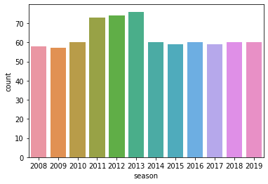

```python
sns.countplot(x='season', data=df)
plt.show()
```

#### TOP player

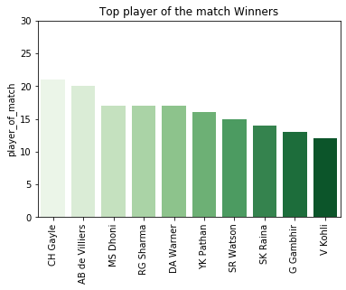

```python
top_players = df.player_of_match.value_counts()[:10]

fig, ax = plt.subplots()
ax.set_ylim([0,30])
ax.set_ylabel("Count")
ax.set_title("Top player of the match Winners")
top_players.plot.bar()
sns.barplot(x = top_players.index, y = top_players, orient='v', palette="Greens");
plt.show()
```

#### Batsmen overview

```python
batsmen = df1.groupby("batsman").agg({'ball': 'count','batsman_runs': 'sum'})
batsmen.rename(columns={'ball':'balls', 'batsman_runs': 'runs'}, inplace=True)
batsmen = batsmen.sort_values(['balls','runs'], ascending=False)
batsmen['batting_strike_rate'] = batsmen['runs']/batsmen['balls'] * 100
batsmen['batting_strike_rate'] = batsmen['batting_strike_rate'].round(2)
batsmen.head(10)
```

| batsman | balls | runs | batting_strike_rate |
| --- | --- | --- | --- |
| V Kohli | 4211 | 5434 | 129.04 |
| SK Raina | 4044 | 5415 | 133.90 |
| RG Sharma | 3816 | 4914 | 128.77 |
| S Dhawan | 3776 | 4632 | 122.67 |
| G Gambhir | 3524 | 4223 | 119.84 |
| RV Uthappa | 3492 | 4446 | 127.32 |
| DA Warner | 3398 | 4741 | 139.52 |
| MS Dhoni | 3318 | 4477 | 134.93 |
| AM Rahane | 3215 | 3850 | 119.75 |
| CH Gayle | 3131 | 4560 | 145.64 |

```python
#utility function used later
def trybuild(lookuplist, buildlist):
    alist = []
    for i in buildlist.index:
        try:
            #print(i)
            alist.append(lookuplist[i])
            #print(alist)
        except KeyError:
            #print('except')
            alist.append(0)
    return alist
```

```python
TopBatsman = batsmen.sort_values(['balls','runs'], ascending=False)[:20]
TopBatsman
```

| batsman | balls | runs | batting_strike_rate |
| --- | --- | --- | --- |
| V Kohli | 4211 | 5434 | 129.04 |
| SK Raina | 4044 | 5415 | 133.90 |
| RG Sharma | 3816 | 4914 | 128.77 |
| S Dhawan | 3776 | 4632 | 122.67 |
| G Gambhir | 3524 | 4223 | 119.84 |
| RV Uthappa | 3492 | 4446 | 127.32 |
| DA Warner | 3398 | 4741 | 139.52 |
| MS Dhoni | 3318 | 4477 | 134.93 |
| AM Rahane | 3215 | 3850 | 119.75 |
| CH Gayle | 3131 | 4560 | 145.64 |
| AB de Villiers | 2977 | 4428 | 148.74 |
| KD Karthik | 2890 | 3688 | 127.61 |
| AT Rayudu | 2681 | 3326 | 124.06 |
| SR Watson | 2639 | 3614 | 136.95 |
| PA Patel | 2444 | 2874 | 117.59 |
| MK Pandey | 2425 | 2872 | 118.43 |
| YK Pathan | 2334 | 3241 | 138.86 |
| JH Kallis | 2291 | 2427 | 105.94 |
| BB McCullum | 2272 | 2893 | 127.33 |
| Yuvraj Singh | 2207 | 2765 | 125.28 |

```python
alist = []
for r in df1.batsman_runs.unique():
    lookuplist = df1[df1.batsman_runs == r].groupby('batsman')['batsman'].count()
    batsmen[str(r) + 's'] = trybuild(lookuplist, batsmen)
    try:
        alist.append(lookuplist[r])
    except KeyError:
        alist.append(0)
TopBatsman = batsmen.sort_values(['balls','runs'], ascending=False)[:20]
TopBatsman.head(10)
```

| batsman | balls | runs | batting_strike_rate | 0s | 4s | 1s | 6s | 3s | 2s | 5s | 7s |
| --- | --- | --- | --- | --- | --- | --- | --- | --- | --- | --- | --- |
| V Kohli | 4211 | 5434 | 129.04 | 1493 | 482 | 1741 | 191 | 11 | 293 | 0 | 0 |
| SK Raina | 4044 | 5415 | 133.90 | 1381 | 495 | 1695 | 195 | 11 | 266 | 1 | 0 |
| RG Sharma | 3816 | 4914 | 128.77 | 1390 | 431 | 1589 | 194 | 5 | 205 | 1 | 1 |
| S Dhawan | 3776 | 4632 | 122.67 | 1455 | 526 | 1473 | 96 | 18 | 205 | 3 | 0 |
| G Gambhir | 3524 | 4223 | 119.84 | 1351 | 492 | 1358 | 59 | 15 | 249 | 0 | 0 |
| RV Uthappa | 3492 | 4446 | 127.32 | 1382 | 436 | 1295 | 156 | 13 | 206 | 4 | 0 |
| DA Warner | 3398 | 4741 | 139.52 | 1254 | 459 | 1213 | 181 | 18 | 271 | 2 | 0 |
| MS Dhoni | 3318 | 4477 | 134.93 | 1111 | 297 | 1383 | 207 | 14 | 304 | 0 | 2 |
| AM Rahane | 3215 | 3850 | 119.75 | 1198 | 405 | 1308 | 74 | 15 | 214 | 1 | 0 |
| CH Gayle | 3131 | 4560 | 145.64 | 1423 | 376 | 919 | 327 | 3 | 83 | 0 | 0 |

```python
#Build a dictionary of Matches player by each batsman
played = {}
def BuildPlayedDict(x):
    #print(x.shape, x.shape[0], x.shape[1])
    for p in x.batsman.unique():
        if p in played:
            played[p] += 1
        else:
            played[p] = 1

df1.groupby('match_id').apply(BuildPlayedDict)
import operator
```

```python
TopBatsman['matches_played'] = [played[p] for p in TopBatsman.index]
TopBatsman['average']= TopBatsman['runs']/TopBatsman['matches_played']

TopBatsman['6s/match'] = TopBatsman['6s']/TopBatsman['matches_played']
TopBatsman['6s/match'].median()

TopBatsman['4s/match'] = TopBatsman['4s']/TopBatsman['matches_played']
TopBatsman['4s/match']
TopBatsman
```

| batsman | balls | runs | batting_strike_rate | 0s | 4s | 1s | 6s | 3s | 2s | 5s | 7s | matches_played | average | 6s/match | 4s/match |
| --- | --- | --- | --- | --- | --- | --- | --- | --- | --- | --- | --- | --- | --- | --- | --- |
| V Kohli | 4211 | 5434 | 129.04 | 1493 | 482 | 1741 | 191 | 11 | 293 | 0 | 0 | 169 | 32.153846 | 1.130178 | 2.852071 |
| SK Raina | 4044 | 5415 | 133.90 | 1381 | 495 | 1695 | 195 | 11 | 266 | 1 | 0 | 189 | 28.650794 | 1.031746 | 2.619048 |
| RG Sharma | 3816 | 4914 | 128.77 | 1390 | 431 | 1589 | 194 | 5 | 205 | 1 | 1 | 182 | 27.000000 | 1.065934 | 2.368132 |
| S Dhawan | 3776 | 4632 | 122.67 | 1455 | 526 | 1473 | 96 | 18 | 205 | 3 | 0 | 158 | 29.316456 | 0.607595 | 3.329114 |
| G Gambhir | 3524 | 4223 | 119.84 | 1351 | 492 | 1358 | 59 | 15 | 249 | 0 | 0 | 151 | 27.966887 | 0.390728 | 3.258278 |
| RV Uthappa | 3492 | 4446 | 127.32 | 1382 | 436 | 1295 | 156 | 13 | 206 | 4 | 0 | 170 | 26.152941 | 0.917647 | 2.564706 |
| DA Warner | 3398 | 4741 | 139.52 | 1254 | 459 | 1213 | 181 | 18 | 271 | 2 | 0 | 126 | 37.626984 | 1.436508 | 3.642857 |
| MS Dhoni | 3318 | 4477 | 134.93 | 1111 | 297 | 1383 | 207 | 14 | 304 | 0 | 2 | 170 | 26.335294 | 1.217647 | 1.747059 |
| AM Rahane | 3215 | 3850 | 119.75 | 1198 | 405 | 1308 | 74 | 15 | 214 | 1 | 0 | 132 | 29.166667 | 0.560606 | 3.068182 |
| CH Gayle | 3131 | 4560 | 145.64 | 1423 | 376 | 919 | 327 | 3 | 83 | 0 | 0 | 124 | 36.774194 | 2.637097 | 3.032258 |
| AB de Villiers | 2977 | 4428 | 148.74 | 940 | 357 | 1231 | 214 | 15 | 220 | 0 | 0 | 142 | 31.183099 | 1.507042 | 2.514085 |
| KD Karthik | 2890 | 3688 | 127.61 | 1013 | 358 | 1201 | 101 | 6 | 208 | 3 | 0 | 162 | 22.765432 | 0.623457 | 2.209877 |
| AT Rayudu | 2681 | 3326 | 124.06 | 947 | 278 | 1179 | 120 | 1 | 156 | 0 | 0 | 138 | 24.101449 | 0.869565 | 2.014493 |
| SR Watson | 2639 | 3614 | 136.95 | 1100 | 344 | 875 | 177 | 9 | 132 | 2 | 0 | 130 | 27.800000 | 1.361538 | 2.646154 |
| PA Patel | 2444 | 2874 | 117.59 | 1061 | 366 | 831 | 49 | 8 | 128 | 1 | 0 | 136 | 21.132353 | 0.360294 | 2.691176 |
| MK Pandey | 2425 | 2872 | 118.43 | 889 | 253 | 1024 | 76 | 8 | 173 | 2 | 0 | 119 | 24.134454 | 0.638655 | 2.126050 |
| YK Pathan | 2334 | 3241 | 138.86 | 856 | 264 | 892 | 161 | 5 | 156 | 0 | 0 | 153 | 21.183007 | 1.052288 | 1.725490 |
| JH Kallis | 2291 | 2427 | 105.94 | 982 | 255 | 888 | 44 | 8 | 113 | 1 | 0 | 95 | 25.547368 | 0.463158 | 2.684211 |
| BB McCullum | 2272 | 2893 | 127.33 | 1022 | 293 | 720 | 129 | 3 | 103 | 1 | 1 | 109 | 26.541284 | 1.183486 | 2.688073 |
| Yuvraj Singh | 2207 | 2765 | 125.28 | 967 | 218 | 750 | 149 | 3 | 120 | 0 | 0 | 126 | 21.944444 | 1.182540 | 1.730159 |

#### Total runs by each batsmen

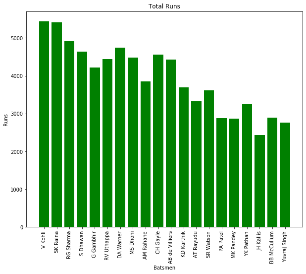

```python
plt.figure(figsize=(10,8))
plt.bar(np.arange(len(TopBatsman)),TopBatsman['runs'],color='g')
plt.xticks(ticks=np.arange(len(TopBatsman)),labels=TopBatsman.index,rotation=90)
plt.xlabel('Batsmen')
plt.ylabel('Runs')
plt.title('Total Runs')
plt.show()
```

#### each batsmen strike rate

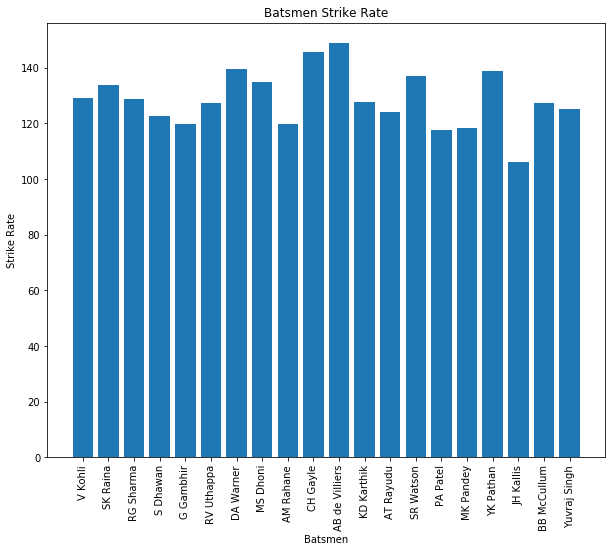

```python
plt.figure(figsize=(10,8))
plt.bar(np.arange(len(TopBatsman)),TopBatsman['batting_strike_rate'])
plt.xticks(ticks=np.arange(len(TopBatsman)),labels=TopBatsman.index,rotation=90)
plt.xlabel('Batsmen')
plt.ylabel('Strike Rate')
plt.title('Batsmen Strike Rate')
plt.show()
```

It is an important factor for a batsman in an T20 league to maintain a good strike rate. AB de Villiers and CH Gayle have almost equal strike rates.

##### bowler information

```python
bowler_wickets = df1.groupby('bowler').aggregate({'ball': 'count', 'total_runs': 'sum', 'player_dismissed' : 'count'})
bowler_wickets.columns = ['runs','balls','wickets']
TopBowlers = bowler_wickets.sort_values(['wickets'], ascending=False)[:20]
TopBowlers
```

| bowler | runs | balls | wickets |
| --- | --- | --- | --- |
| SL Malinga | 2974 | 3511 | 188 |
| DJ Bravo | 2711 | 3733 | 168 |
| A Mishra | 3172 | 3850 | 165 |
| Harbhajan Singh | 3451 | 4050 | 161 |
| PP Chawla | 3157 | 4153 | 156 |
| B Kumar | 2707 | 3264 | 141 |
| R Ashwin | 3016 | 3391 | 138 |
| SP Narine | 2600 | 2939 | 137 |
| UT Yadav | 2605 | 3640 | 136 |
| R Vinay Kumar | 2186 | 3043 | 127 |
| A Nehra | 1974 | 2537 | 121 |
| Z Khan | 2276 | 2860 | 119 |
| RA Jadeja | 2541 | 3221 | 116 |
| SR Watson | 2137 | 2751 | 107 |
| DW Steyn | 2207 | 2454 | 104 |
| YS Chahal | 1841 | 2416 | 102 |
| P Kumar | 2637 | 3342 | 102 |
| RP Singh | 1874 | 2417 | 100 |
| PP Ojha | 1945 | 2399 | 99 |
| MM Sharma | 1770 | 2457 | 99 |

```python
TopBowlers['economy'] = TopBowlers['runs']/(TopBowlers['balls']/6)
TopBowlers = TopBowlers.sort_values(['economy'], ascending=True)[:20]
TopBowlers
```

| bowler | runs | balls | wickets | economy |
| --- | --- | --- | --- | --- |
| UT Yadav | 2605 | 3640 | 136 | 4.293956 |
| R Vinay Kumar | 2186 | 3043 | 127 | 4.310220 |
| MM Sharma | 1770 | 2457 | 99 | 4.322344 |
| DJ Bravo | 2711 | 3733 | 168 | 4.357353 |
| PP Chawla | 3157 | 4153 | 156 | 4.561040 |
| YS Chahal | 1841 | 2416 | 102 | 4.572020 |
| RP Singh | 1874 | 2417 | 100 | 4.652048 |
| SR Watson | 2137 | 2751 | 107 | 4.660851 |
| A Nehra | 1974 | 2537 | 121 | 4.668506 |
| RA Jadeja | 2541 | 3221 | 116 | 4.733313 |
| P Kumar | 2637 | 3342 | 102 | 4.734291 |
| Z Khan | 2276 | 2860 | 119 | 4.774825 |
| PP Ojha | 1945 | 2399 | 99 | 4.864527 |
| A Mishra | 3172 | 3850 | 165 | 4.943377 |
| B Kumar | 2707 | 3264 | 141 | 4.976103 |
| SL Malinga | 2974 | 3511 | 188 | 5.082313 |
| Harbhajan Singh | 3451 | 4050 | 161 | 5.112593 |
| SP Narine | 2600 | 2939 | 137 | 5.307928 |
| R Ashwin | 3016 | 3391 | 138 | 5.336479 |
| DW Steyn | 2207 | 2454 | 104 | 5.396088 |

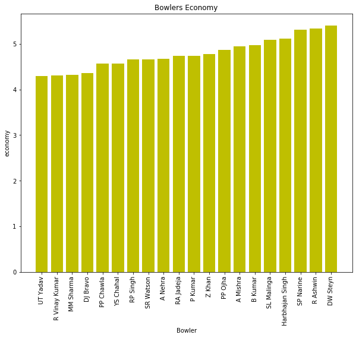

```python
plt.figure(figsize=(10,8))
plt.bar(np.arange(len(TopBowlers)),TopBowlers['economy'],color='y')
plt.xticks(ticks=np.arange(len(TopBowlers)),labels=TopBowlers.index,rotation=90)
plt.xlabel('Bowler')
plt.ylabel('economy')
plt.title('Bowlers Economy')
plt.show()
```

```python
# economy has to be low
```

#### Wickets taken by a bowler

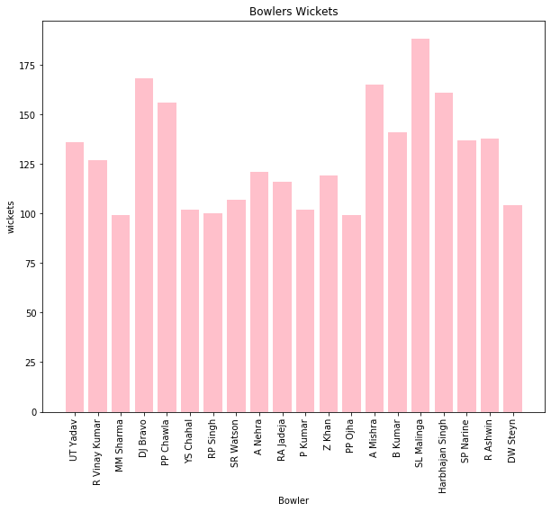

```python
plt.figure(figsize=(10,8))
plt.bar(np.arange(len(TopBowlers)),TopBowlers['wickets'],color='pink')
plt.xticks(ticks=np.arange(len(TopBowlers)),labels=TopBowlers.index,rotation=90)
plt.xlabel('Bowler')
plt.ylabel('wickets')
plt.title('Bowlers Wickets')
plt.show()
```

### Observation and conclusion

#### SL Malinga and DJ Bravo are the leading wicket takers in this tournament.

##### Best Pick for endorsement :

#### Batsmen:

*Virat kohli,SK Raina,CH Gayle,AB de Villiers,DA warner*

#### Bowlers:

*UT Yadhav,DJ Bravo,SL Malinga*

#### Teams:

MUMBAI INDIANS,CHENNAI SUPER KINGS,KOLKATA KNIGHT RIDERS